# Default prediction for Lending Club data

## Conclusions

Authors : Iker Aguirre, Carlos Serrano

Date : 04/12/2020

```python
import numpy as np
import pandas as pd
import seaborn as sns
import matplotlib.pyplot as plt
from matplotlib import pyplot
%matplotlib inline
```

```python
def features_importance(coeficients):
    data = {'Features':x_train.columns, 'Coeficients':abs(coeficients)}
    coef = pd.DataFrame(data).sort_values(by=['Coeficients'], ascending=False)
    fig, ax = pyplot.subplots(figsize=(12,10))
    coef_plot = sns.barplot(coef['Features'],coef['Coeficients'])
    coef_plot.set_xticklabels(coef_plot.get_xticklabels(), rotation=40, ha="right");
```

```python
lc_data = pd.read_csv("lc_cleaned.csv")
lc_data.drop('Unnamed: 0', inplace=True, axis=1)
lc_data = lc_data.dropna()
```

```python
lc_data
```

|  | funded_amnt | int_rate | annual_inc | loan_status | dti | delinq_2yrs | fico_range_low | inq_last_6mths | open_acc | pub_rec | ... | num_tl_op_past_12m | pct_tl_nvr_dlq | pub_rec_bankruptcies | tax_liens | total_bal_ex_mort | home_ownership_cat | verification_status_cat | application_type_Joint App | hardship_flag_Y | debt_settlement_flag_Y |
| --- | --- | --- | --- | --- | --- | --- | --- | --- | --- | --- | --- | --- | --- | --- | --- | --- | --- | --- | --- | --- | --- |
| 0 | -0.090625 | -0.9024 | 2.000000 | 0.0 | -0.075856 | 0.0 | 1.000000 | 0.0 | 1.285714 | 1.0 | ... | 0.0 | -0.206897 | 1.0 | 0.0 | 1.523500 | 0.0 | -0.5 | 0.0 | 0.0 | 0.0 |
| 1 | -0.455208 | 1.8976 | -0.340909 | 0.0 | -0.966558 | 0.0 | 0.000000 | 0.0 | -1.000000 | 0.0 | ... | -1.0 | -2.011494 | 0.0 | 0.0 | -0.777654 | 0.5 | 0.0 | 0.0 | 0.0 | 0.0 |
| 2 | -0.430208 | -0.9024 | 1.022727 | 0.0 | -0.391517 | 0.0 | 0.714286 | 2.0 | 1.142857 | 0.0 | ... | 0.5 | 0.287356 | 0.0 | 0.0 | 0.197300 | -0.5 | -0.5 | 0.0 | 0.0 | 0.0 |
| 3 | -0.221875 | 0.4848 | -0.295932 | 0.0 | -0.637031 | 0.0 | 0.142857 | 0.0 | 0.571429 | 2.0 | ... | 0.5 | 0.287356 | 2.0 | 0.0 | -0.648005 | 0.5 | 0.0 | 0.0 | 0.0 | 0.0 |
| 4 | 0.111458 | 0.4848 | 0.227273 | 0.0 | -0.575856 | 1.0 | 0.000000 | 0.0 | -1.000000 | 0.0 | ... | 0.5 | -0.862069 | 0.0 | 0.0 | -0.243986 | -0.5 | 0.5 | 0.0 | 0.0 | 0.0 |
| ... | ... | ... | ... | ... | ... | ... | ... | ... | ... | ... | ... | ... | ... | ... | ... | ... | ... | ... | ... | ... | ... |
| 456681 | -0.090625 | 0.4160 | -0.900000 | 0.0 | 0.747145 | 0.0 | -0.142857 | 0.0 | -0.285714 | 0.0 | ... | -0.5 | 0.287356 | 0.0 | 0.0 | -0.434451 | 0.5 | 0.5 | 0.0 | 0.0 | 0.0 |
| 456682 | -0.055208 | -0.1600 | -0.045455 | -1.0 | 0.470636 | 1.0 | 0.000000 | 0.0 | 0.285714 | 0.0 | ... | 0.5 | 0.091954 | 0.0 | 0.0 | 1.816346 | -0.5 | 0.5 | 0.0 | 0.0 | 0.0 |
| 456683 | 0.028125 | 0.4800 | -0.681818 | -1.0 | 1.058728 | 0.0 | -0.142857 | 0.0 | -0.285714 | 1.0 | ... | 0.5 | 0.287356 | 1.0 | 0.0 | -0.087141 | 0.5 | 0.5 | 0.0 | 0.0 | 0.0 |
| 456684 | -0.055208 | 1.1200 | -0.013636 | -1.0 | 0.756117 | 1.0 | 0.285714 | 2.0 | 0.857143 | 0.0 | ... | 0.0 | -0.287356 | 0.0 | 0.0 | 0.498309 | 0.5 | 0.0 | 0.0 | 0.0 | 0.0 |
| 456685 | 0.611458 | -0.1600 | 0.795455 | 0.0 | -0.578303 | 0.0 | -0.285714 | 1.0 | -0.428571 | 1.0 | ... | -0.5 | 0.287356 | 0.0 | 1.0 | -0.108178 | 0.5 | 0.5 | 0.0 | 0.0 | 0.0 |

456686 rows × 43 columns

```python
y = lc_data['loan_status']
X = lc_data.drop('loan_status', axis=1)
```

```python
from sklearn.model_selection import train_test_split

x_train, x_test, y_train, y_test = train_test_split(X, y, test_size=0.25, random_state=42, stratify=y)
```

```python
import pickle
load_lr = pickle.load(open("lr_model2.sav", 'rb'))
load_svm = pickle.load(open("svm_model2.sav", 'rb'))
load_rf = pickle.load(open("rf_model2.sav", 'rb'))
load_xgboostt = pickle.load(open("xgb_model2.sav", 'rb'))
```

```python
from sklearn.linear_model import LogisticRegression
from sklearn import preprocessing
from sklearn import svm
from sklearn.ensemble import RandomForestClassifier
from sklearn.model_selection import GridSearchCV
from sklearn.metrics import accuracy_score
import xgboost as xgb
from xgboost import XGBClassifier
from sklearn.metrics import accuracy_score
from sklearn.metrics import plot_confusion_matrix
from sklearn import metrics
import scikitplot as skplt
from sklearn.metrics import classification_report, confusion_matrix, roc_curve, auc, \
                            silhouette_score, recall_score, precision_score, make_scorer, \
                            roc_auc_score, f1_score, precision_recall_curve
```

## Results

### Logistic Regression

```python
y_pred = load_lr.predict(x_test)
```

```python
print("Classification Report")
print(classification_report(y_test, y_pred))
```

```
Classification Report
              precision    recall  f1-score   support

        -1.0       0.88      0.90      0.89     28793
         0.0       0.97      0.96      0.96     85379

    accuracy                           0.95    114172
   macro avg       0.93      0.93      0.93    114172
weighted avg       0.95      0.95      0.95    114172
```

```python
y_pred_proba = load_lr.predict_proba(x_test)
```

```
Accuracy train:  0.946615320833601
Accuracy test: 0.9455470693339874
```

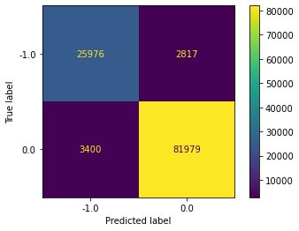

```python
plot_confusion_matrix(load_lr, x_test, y_test)

print("Accuracy train: ", metrics.accuracy_score(y_train, load_lr.predict(x_train)))
print("Accuracy test:",metrics.accuracy_score(y_test, y_pred))
```

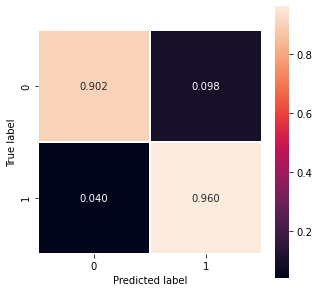

```python
cm = confusion_matrix(y_test, y_pred)
cm = cm.astype('float') / cm.sum(axis=1)[:, np.newaxis]

plt.figure(figsize=(5,5))
sns.heatmap(cm, annot=True, fmt=".3f", linewidths=.5, square = True);
plt.ylabel('True label');
plt.xlabel('Predicted label');
```

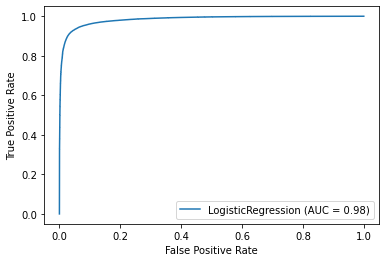

```python
metrics.plot_roc_curve(load_lr, x_test, y_test)
plt.show()
```

Hence, we have really high levels of precision and recall with our Logistic Regression. In our case, we will be focusing on the precision metric because our positives represent the case when the loan is fully paid, and the negatives represent otherwise. So, theoretically, our model would be good in accounting for those people who are categorized as clients that will pay but end up entering in default. That error is the one we need to minimize, because conceding a loan which won´t be paid could very very costly for company.

As there are high levels of both precision and recall, we can see a rectangular trade-off between the two in the pr-curve now presented:

```python
# Select only positive cases
yhat = y_pred_proba[:, 1]
```

```python
# Calculate pr-curve
precision, recall, thresholds = precision_recall_curve(y_test, yhat, pos_label=0)
```

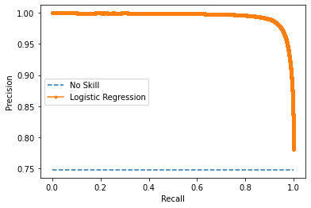

```python
no_skill = len(y_test[y_test==0]) / len(y_test)
pyplot.plot([0,1], [no_skill,no_skill], linestyle='--', label='No Skill')
pyplot.plot(recall, precision, marker='.', label='Logistic Regression')
# axis labels
pyplot.xlabel('Recall')
pyplot.ylabel('Precision')
pyplot.legend()
# show the plot
pyplot.show()
```

#### Cumulative Gains Curve

We can also assess the cumulative gains curve and the lift curve. These are good measures of the perfomance of our model.

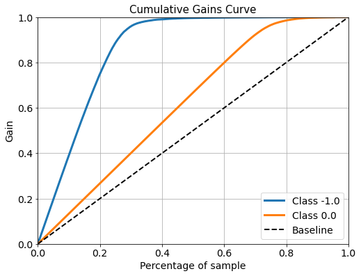

```python
skplt.metrics.plot_cumulative_gain(
    y_test, y_pred_proba, figsize=(8, 6), title_fontsize=15, text_fontsize=14
)
plt.show()
```

On the other hand, the Lift Curve indicates how many times more than average targets are included in each group.

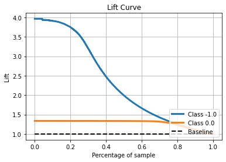

```python
skplt.metrics.plot_lift_curve(y_test, y_pred_proba)
plt.show()
```

[figure not shown]

### Support Vector Machine

```python
y_pred = load_svm.predict(x_test)
```

```python
print("Classification Report")
print(classification_report(y_test, y_pred))
```

```
Classification Report
              precision    recall  f1-score   support

        -1.0       0.93      0.17      0.29     28793
         0.0       0.78      1.00      0.88     85379

    accuracy                           0.79    114172
   macro avg       0.86      0.58      0.58    114172
weighted avg       0.82      0.79      0.73    114172
```

```
Accuracy train:  0.787299205287959
Accuracy test: 0.7876449567319483
```

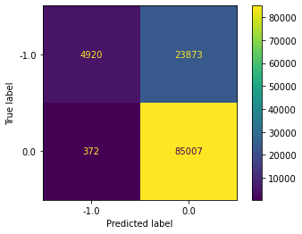

```python
plot_confusion_matrix(load_svm, x_test, y_test)
print("Accuracy train: ", metrics.accuracy_score(y_train, load_svm.predict(x_train)))
print("Accuracy test:",metrics.accuracy_score(y_test, y_pred))
```

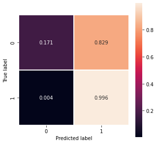

```python
cm = confusion_matrix(y_test, y_pred)
cm = cm.astype('float') / cm.sum(axis=1)[:, np.newaxis]

plt.figure(figsize=(5,5))
sns.heatmap(cm, annot=True, fmt=".3f", linewidths=.5, square = True);
plt.ylabel('True label');
plt.xlabel('Predicted label');
```

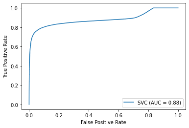

```python
metrics.plot_roc_curve(load_svm, x_test, y_test)
plt.show()
```

For the SVM model we observe a significantly lower accuracy than the one seen in the Logistic Regression. Although lower than the basis model, the SVM also presents a high AUC.

However, the model is predicting poorly the default cases, resulting in a high false positive rate which is the error we are trying to minimize.

### Random Forest

```python
y_pred = load_rf.predict(x_test)
```

```python
print("Classification Report")
print(classification_report(y_test, y_pred))
```

```
Classification Report
              precision    recall  f1-score   support

        -1.0       0.91      0.94      0.92     28793
         0.0       0.98      0.97      0.97     85379

    accuracy                           0.96    114172
   macro avg       0.94      0.95      0.95    114172
weighted avg       0.96      0.96      0.96    114172
```

```python
y_pred_proba = load_rf.predict_proba(x_test)
```

```
Accuracy train:  0.9619052067944668
Accuracy test: 0.9607084048628385
```

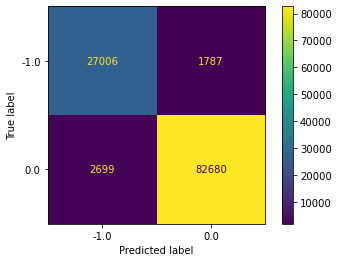

```python
plot_confusion_matrix(load_rf, x_test, y_test)
print("Accuracy train: ", metrics.accuracy_score(y_train, load_rf.predict(x_train)))
print("Accuracy test:",metrics.accuracy_score(y_test, y_pred))
```

[figure not shown]

```python
cm = confusion_matrix(y_test, y_pred)
cm = cm.astype('float') / cm.sum(axis=1)[:, np.newaxis]

plt.figure(figsize=(5,5))
sns.heatmap(cm, annot=True, fmt=".3f", linewidths=.5, square = True);
plt.ylabel('True label');
plt.xlabel('Predicted label');
```

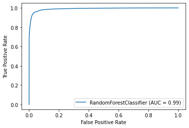

```python
metrics.plot_roc_curve(load_rf, x_test, y_test)
plt.show()
```

```python
yhat = y_pred_proba[:, 1]
```

```python
# calculate pr-curve
precision, recall, thresholds = precision_recall_curve(y_test, yhat, pos_label=0)
```

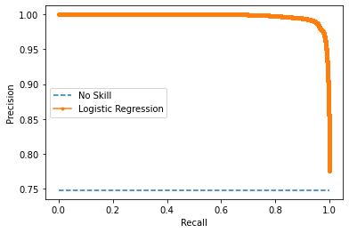

```python
no_skill = len(y_test[y_test==0]) / len(y_test)
pyplot.plot([0,1], [no_skill,no_skill], linestyle='--', label='No Skill')
pyplot.plot(recall, precision, marker='.', label='Logistic Regression')
# axis labels
pyplot.xlabel('Recall')
pyplot.ylabel('Precision')
pyplot.legend()
# show the plot
pyplot.show()
```

#### Cumulative Gains Curve

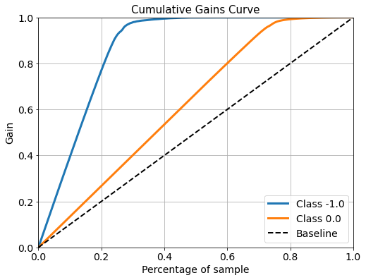

```python
skplt.metrics.plot_cumulative_gain(
    y_test, y_pred_proba, figsize=(8, 6), title_fontsize=15, text_fontsize=14
)
plt.show()
```

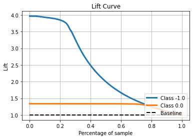

```python
skplt.metrics.plot_lift_curve(y_test, y_pred_proba)
plt.show()
```

### XGBoost

```python
y_pred = load_xgboostt.predict(x_test)
```

```python
print("Classification Report")
print(classification_report(y_test, y_pred))
```

```
Classification Report
              precision    recall  f1-score   support

        -1.0       0.94      0.95      0.95     28793
         0.0       0.98      0.98      0.98     85379

    accuracy                           0.97    114172
   macro avg       0.96      0.97      0.96    114172
weighted avg       0.97      0.97      0.97    114172
```

```python
y_pred_proba = load_xgboostt.predict_proba(x_test)
```

```
Accuracy train:  0.9822021873558453
Accuracy test: 0.972742879164769
```

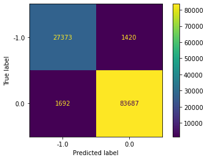

```python
plot_confusion_matrix(load_xgboostt, x_test, y_test)
print("Accuracy train: ", metrics.accuracy_score(y_train, load_xgboostt.predict(x_train)))
print("Accuracy test:",metrics.accuracy_score(y_test, y_pred))
```

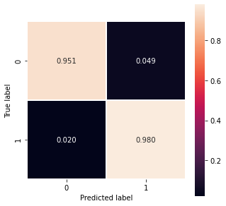

```python
cm = confusion_matrix(y_test, y_pred)
cm = cm.astype('float') / cm.sum(axis=1)[:, np.newaxis]

plt.figure(figsize=(5,5))
sns.heatmap(cm, annot=True, fmt=".3f", linewidths=.5, square = True);
plt.ylabel('True label');
plt.xlabel('Predicted label');
```

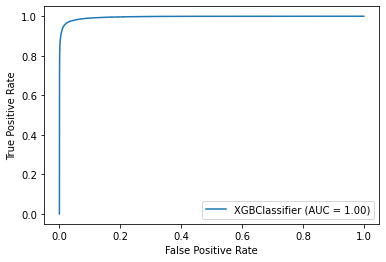

```python
metrics.plot_roc_curve(load_xgboostt, x_test, y_test)
plt.show()
```

```python
yhat = y_pred_proba[:, 1]
```

```python
# calculate pr-curve
precision, recall, thresholds = precision_recall_curve(y_test, yhat, pos_label=0)
```

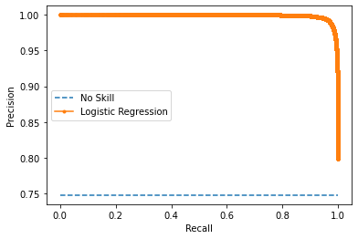

```python
no_skill = len(y_test[y_test==0]) / len(y_test)
pyplot.plot([0,1], [no_skill,no_skill], linestyle='--', label='No Skill')
pyplot.plot(recall, precision, marker='.', label='Logistic Regression')
# axis labels
pyplot.xlabel('Recall')
pyplot.ylabel('Precision')
pyplot.legend()
# show the plot
pyplot.show()
```

#### Cumulative Gains Curve

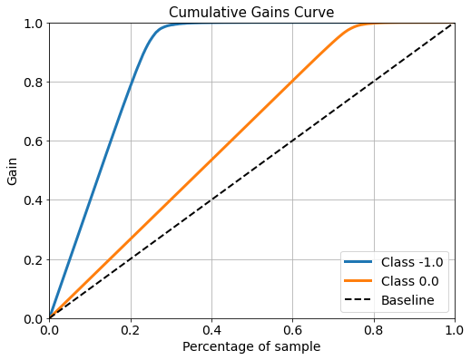

```python
skplt.metrics.plot_cumulative_gain(
    y_test, y_pred_proba, figsize=(8, 6), title_fontsize=15, text_fontsize=14
)
plt.show()
```

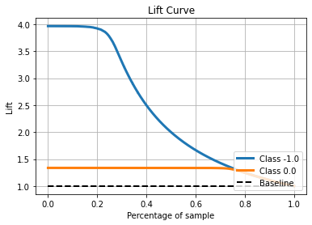

```python
skplt.metrics.plot_lift_curve(y_test, y_pred_proba)
plt.show()
```

For both Random Forest and XGBoost models, we observe again high levels of accuracy and of AUC. They also behave similarly to the logistic regression in the other metrics, which is quite good. Nevertheless, this fantastic perfomance raises some concerns of how well our models are really representing the reality, and therefore how well will these predict the defaults of loans. We will approach these concerns below.

When considering which model would fit better with this classification problem, we would definetly have to choose between either Random Forest or XGBoost, both over a 96% of accuracy, which is quite high.

As we have seen above, our models perform really well and have high levels on the AUC metric as well as in others. However, we fear that these results are biased due to the selection of the predictor variables. It is possible that som of the variables that have been chosen to predict the default, are actually highly correlated with it, and thus, irrelevant for our model. Presumably, these variables reflect data that can only be seen in the future, once the loan is already conceeded but not just right before clearing it.

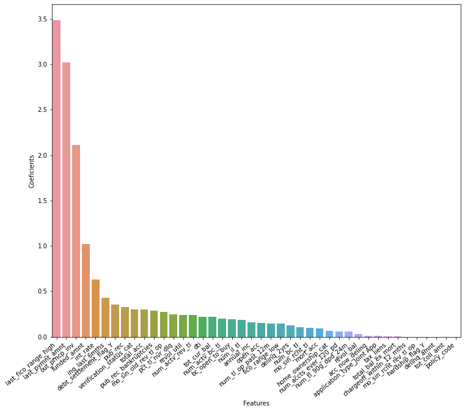

```python
features_importance(load_lr.coef_[0])
```

To try and clarify this, we will proceed by droping from our dataset some variables that we believe are of this type. Then, we will train a model and obtain the AUC metric in order to compare with the first models, which include all variables. We cannot be sure as the clients that are now applying for a loan in LC, could have applied and being conceeded in other institutions before. And therefore, the variables could be referring to previous loans of the clients. To shed some light on this we can visualize the importance of some of the features that we consider should be removed from our model: `last_pymnt_amnt` and `out_prncp_inv`

First we remove those variables.

```python
lc_prueba = lc_data.drop(['revol_bal',
                         'revol_util',
                         'out_prncp_inv',
                         'last_pymnt_amnt',
                         'bc_open_to_buy',
                         'chargeoff_within_12_mths'],
                         axis=1)
```

For computational reasons, we will only test this with a Logistic Regression and the compare to our results presented above.

```python
y_prueba = lc_prueba['loan_status']
X_prueba = lc_prueba.drop('loan_status', axis=1)
```

```python
from sklearn.model_selection import train_test_split

x_train, x_test, y_train, y_test = train_test_split(X_prueba, y_prueba, test_size=0.25, random_state=42, stratify=y)
```

```python
logisticRegr_prueba = LogisticRegression()
logisticRegr_prueba.fit(x_train, y_train)
```

```
LogisticRegression()
```

```python
y_pred = logisticRegr_prueba.predict(x_test)
```

```
Accuracy train:  0.8792925252690401
Accuracy test: 0.8775006131100445
```

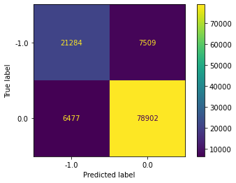

```python
plot_confusion_matrix(logisticRegr_prueba, x_test, y_test)
print("Accuracy train: ", metrics.accuracy_score(y_train, logisticRegr_prueba.predict(x_train)))
print("Accuracy test:",metrics.accuracy_score(y_test, y_pred))
```

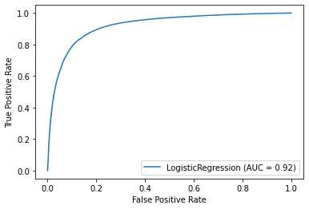

```python
metrics.plot_roc_curve(logisticRegr_prueba, x_test, y_test)
plt.show()
```

We obtain the expected outcome out of this simple test. The AUC is lower than the first logistic regression (0.92 to 0.98). This clearly indicates that there could be a bias because of the inclusion of the variables that can only be seen after the loan is conceeded. Of course, this conclusion calls for a deeper research in order to determine which are those variables and build more reliable models to predict the defaults in loans.

# References

- Scikit-Learn: Hands-on machine learning with Scikit-Learn and TensorFlow / Aurélien Géron (2017)
- https://seaborn.pydata.org/tutorial/distributions.html
- https://medium.com/@szabo.bibor/how-to-create-a-seaborn-correlation-heatmap-in-python-834c0686b88e
- https://seaborn.pydata.org/index.html
- https://towardsdatascience.com/exploratory-data-analysis-eda-python-87178e35b14
- SearchGridCV: https://scikit-learn.org/stable/modules/generated/sklearn.model_selection.GridSearchCV.html
- Logistic Regression: https://scikit-learn.org/stable/modules/generated/sklearn.linear_model.LogisticRegression.html
- SVM: https://scikit-learn.org/stable/modules/generated/sklearn.svm.SVC.html
- Random Forest: https://scikit-learn.org/stable/modules/generated/sklearn.ensemble.RandomForestClassifier.html
- XGBoost: https://www.kaggle.com/stuarthallows/using-xgboost-with-scikit-learn
- https://towardsdatascience.com/meaningful-metrics-cumulative-gains-and-lyft-charts-7aac02fc5c14
- https://scikit-learn.org/stable/modules/generated/sklearn.metrics.precision_recall_curve.html